# Chapter 11

Adam Høj - 201803767

## Info

Når der snakkes op-amp konfigurationer, refereres der til de her to:

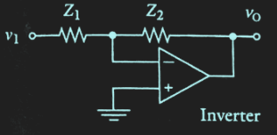

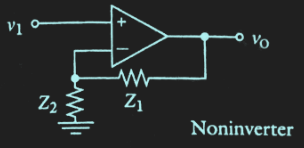

## Noter fra lektion 2020-03-10

## Opgave 3

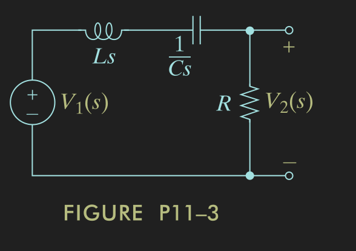

> Find the driving point impedance seen by the voltage source in Figure P11–3 and the voltage transfer function T_V(s) = V_2(s) / V_1(s).

### Driving point impedans:

Dette er simpelt - hvad er $V_1(s)$ ?

$$V_1(s)= V_L + V_R + V_C$$

Omskrevet:

$$V_1(s)= I(s)\left( L s + R + \frac{1}{Cs}\right)$$

Dermed:

$$\frac{V_1(s)}{I(s)}= L s + R + \frac{1}{Cs}$$

Omskrevet:

$$Z(s)=\frac{V_1(s)}{I(s)}= \frac{LCs^2 + RCs +1}{Cs}$$

### Transfer function:

Da det er en spændingsdeler gælder flg.:

$$T_V(s)=\frac{R}{Ls + \frac{1}{Cs}+R}$$

Omskrevet:

$$T_V(s)=\frac{R}{\frac{LCs^2 + RCs +1}{Cs}}$$

$$\boxed{
T_V(s)=\frac{RCs}{LCs^2 + RCs +1}
}$$

[figure not shown]

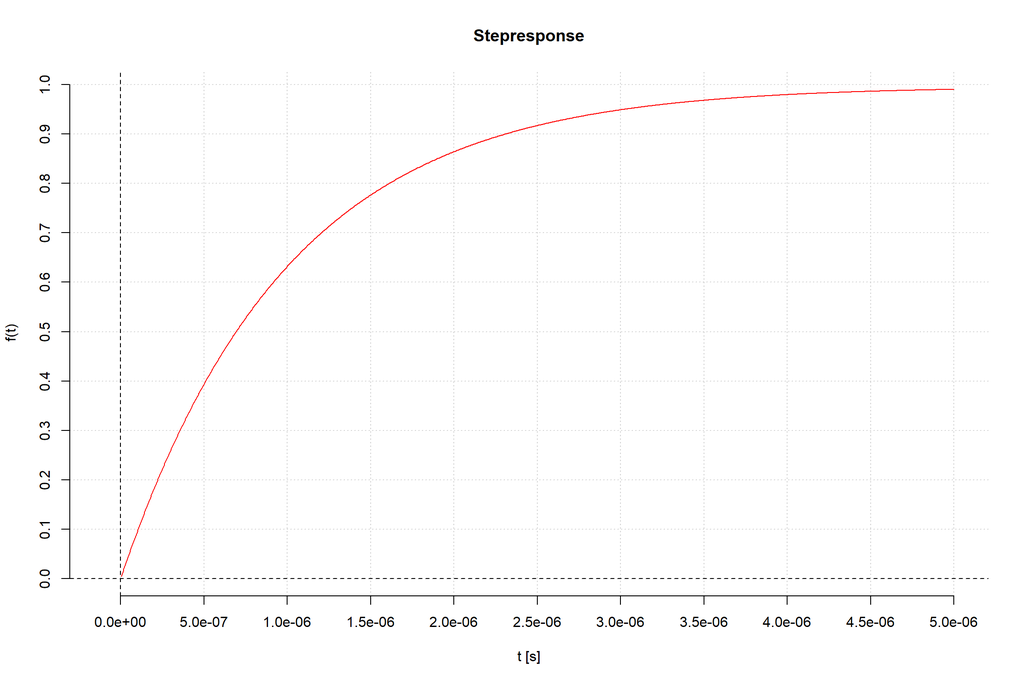

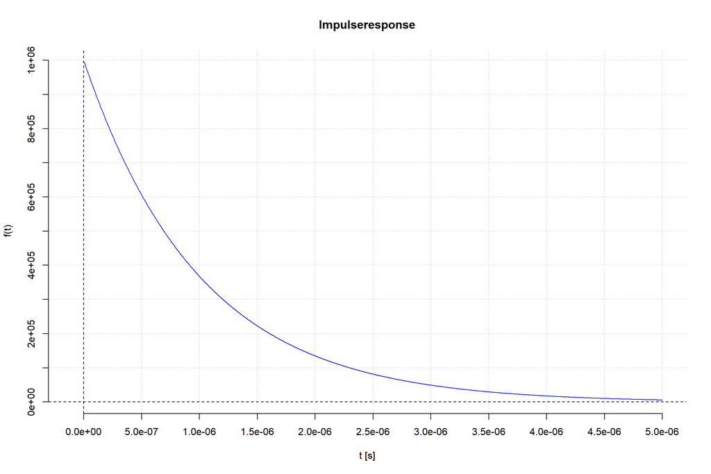

## Opgave 5

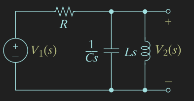

> Find the driving point impedance seen by the voltage source in Figure P11–5 and the voltage transfer function T_V(s) = V_2(s)/V_1(s).

#### Driving pointe impedance $Z_i$

Vi har:

$$-V_1(s) + I_1(s) \cdot\left( R + \frac{1}{Cs}||L s\right) = 0$$

Dermed:

$$Z_i(s) = \frac{V_1(s)}{I_1(s)} = R + \frac{\frac{1}{Cs}\cdot Ls}{\frac{1}{Cs} + Ls}$$

$$Z_i(s) = \frac{V_1(s)}{I_1(s)} = \left(\frac{1}{Ls}\cdot Cs\right)^{-1} + R$$

Dette kan omskrives til:

$$\frac{CLRs^2+Ls+R}{CLs^2+1}$$

#### Voltage transfer function $T_v(s)$

Std. spændingsdeler formel:

$$V_2(s) = V_1(s) \cdot \frac{\frac{1}{Cs}||Ls}{R+\frac{1}{Cs}||Ls} = V_1(s) \cdot \frac{Ls}{R\left(CLs^2+1\right)+Ls}$$

Dermed:

$$T_v(s) = \frac{V_2(s)}{V_1(s)} = \frac{Ls}{R\left(CLs^2+1\right)+Ls} = \frac{Ls}{CLRs^2+Ls+R}$$

#### Resultater:

$$\boxed{
Z_i(s) = \frac{CLRs^2+Ls+R}{CLs^2+1} \; \mathrm{\Omega}
}$$
$$\boxed{
\; T_v(s) = \frac{Ls}{CLRs^2+Ls+R}
}$$

#### Forsøg med værdier.

$$R = 1000\;\mathrm{\Omega} \quad L = 1\;\mathrm{H} \quad C = 1\mathrm{µF}$$

$$Z_i(s) = \frac{10^3\left(s^2+10^3s+10^6\right)}{s^2+10^6} \; \mathrm{\Omega}$$

$$\; T_v(s) = \frac{10^3s}{s^2+10^3s+10^6}$$

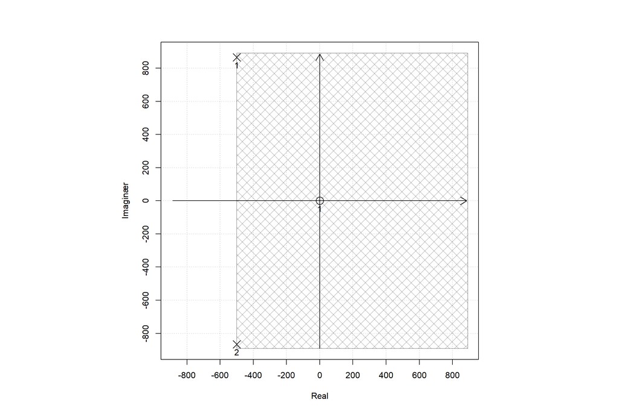

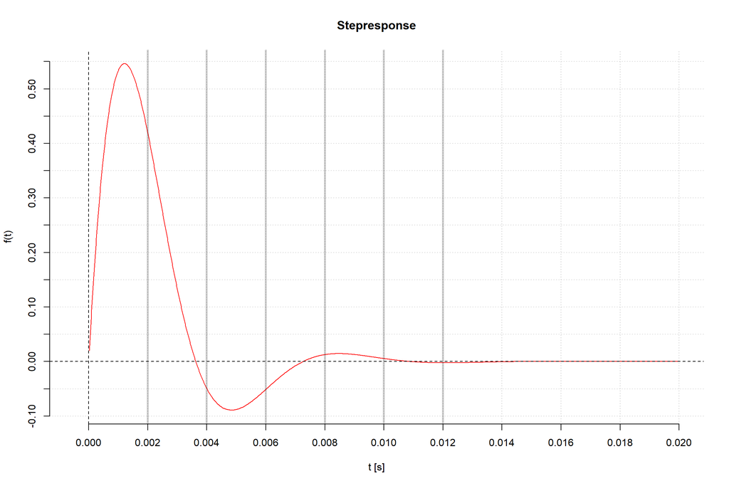

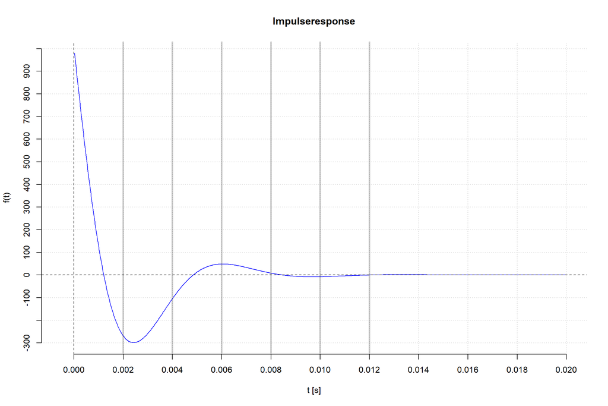

## Opgave 7

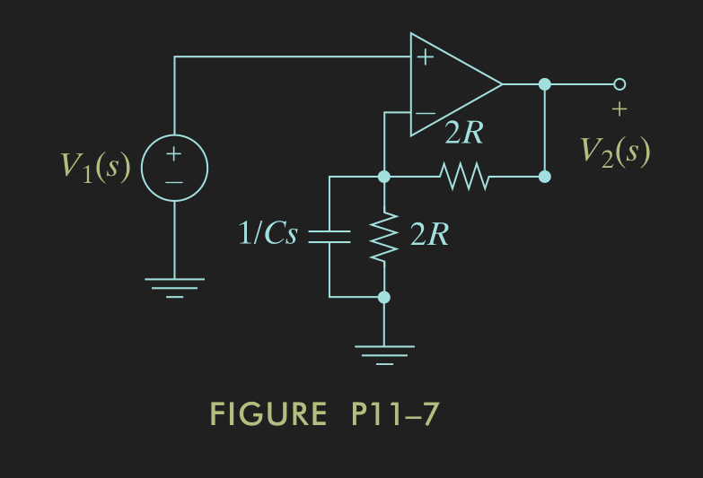

> Find the driving point impedance seen by the voltage source in Figure P11–7 and the voltage transfer function. T_V(s) = V_2(s)/V_1(s).

### Driving point impedans

Da det er en operationsforstærker, antages det at denne er idéel og dermed er $\boxed{Z_{in} =\infty}$.

### Transfer function.

Det er en non-inverterende opstilling - derfor gælder flg.:

$$T_V(s) = \frac{Z_1+Z_2}{Z_2}$$
Hvor:
$$Z_1 = 2R \quad Z_2 = 2R||C$$
$$Z_2 = \frac{2R \cdot \frac{1}{Cs}}{2R+\frac{1}{Cs}}$$
Derfor:
$$T_V(s)=\frac{2R+\frac{2R\frac{1}{Cs}}{2R+\frac{1}{Cs}}}{\frac{2R\frac{1}{Cs}}{2R+\frac{1}{Cs}}}$$

Omskrevet:
$$\boxed{
T_V(s)=2RCs+2
}$$

Med værdierne: $R = 100\;\mathrm{\Omega} \quad C = 0.01\mathrm{µF}$:

[figure not shown]

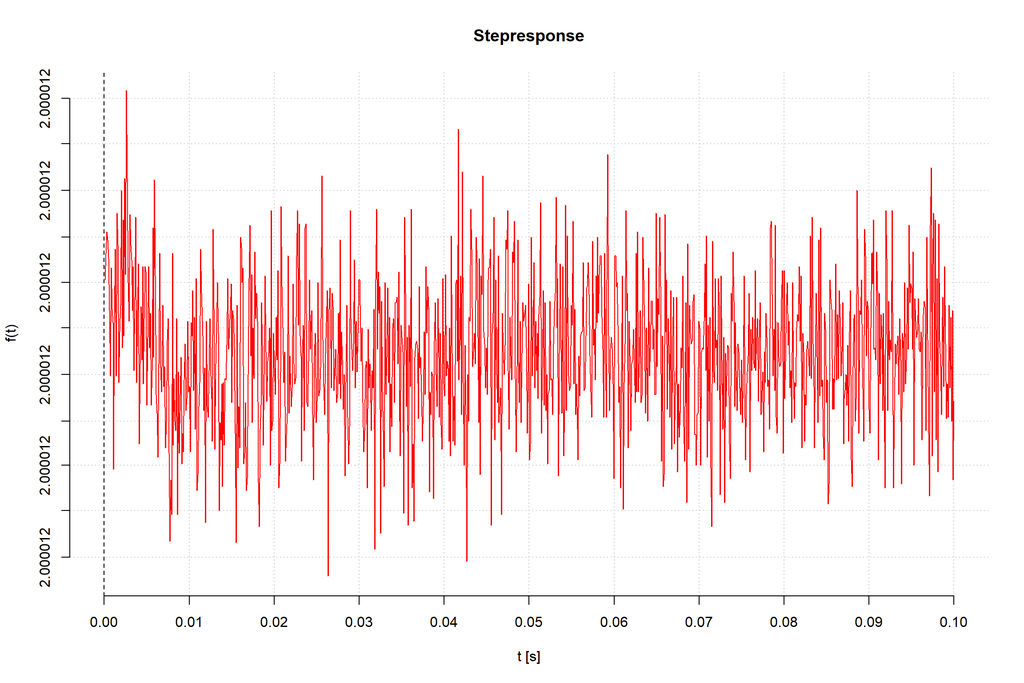

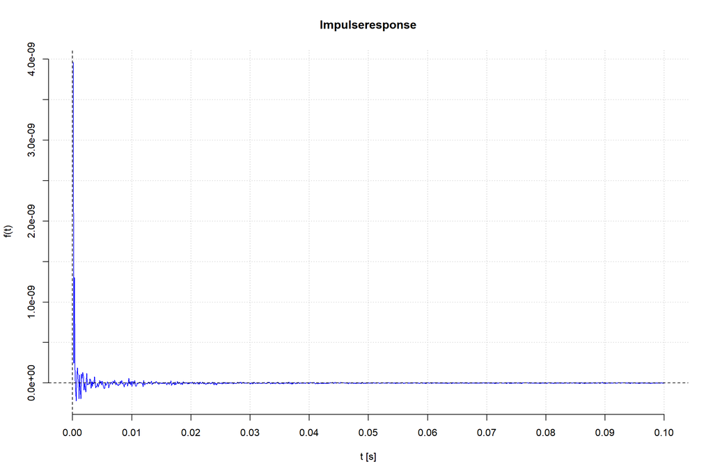

## Opgave 9

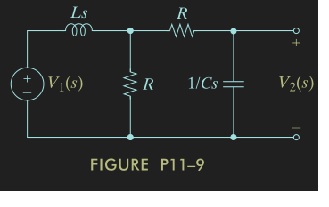

> Find the voltage transfer function T_V(s) = V_2(s)/V_1(s) in Figure P11–9.

**FORKERT!!!!!**

### Transfer function

Dette er to spændingsdelere i serie:

Deler 1:
$$H_1(s) = \frac{R}{L+R}$$

Deler 2
$$H_2(s) = \frac{\frac{1}{Cs}}{\frac{1}{Cs}+R}$$

Dermed kan $T_V(s)$ findes ved
$$T_V(s)= H_1(s)\cdot H_2(s)$$
Altså
$$T_V(s) = \frac{R}{Ls+R} \cdot \frac{\frac{1}{Cs}}{\frac{1}{Cs}+R}$$

$$\boxed{
T_V(s) = \frac{R}{CLRs^2+(CR^2+L)s+R}
}$$

**KORREKT!**

## Opgave 11

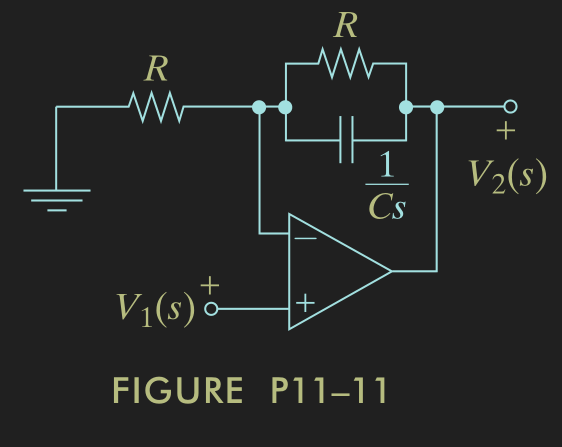

> Find the voltage transfer function T_V(s) = V_2(s) / V_1(s) in Figure P11–11. Select values of R and C so that T_V(s) has a pole at s = -100 krad/s.

#### Voltage transfer function $T_v(s)$

Da det er en ikke-inverterende operationsforstærker gælder flg:
$$V_2 = V_1 \cdot \frac{Z_1+Z_2}{Z_2}$$

Hvor:

$$Z_1 = R||C \quad Z_2 = R$$

Dermed:

$$T_v(s) ) \frac{\left(\frac{1}{R}+Cs\right)^1+R}{R} = \frac{RCs+2}{RCs+1} = \frac{s + \frac{2}{RC}}{s+\frac{1}{RC}}$$

#### Poler i systemet.

For at få en pol i $-100k\;\mathrm{rad/s}$ kigges i nævneren: $s + \frac{1}{RC}$ - hvilket viser at der findes en pol i $\frac{-1}{RC}$.

Derfor:

R vælges:
$$R = 100 \;\mathrm{\Omega}$$
C findes:
$$-100.000 = \frac{-1}{100\cdot C} \to C = 100\mathrm{nF}$$

[figure not shown]

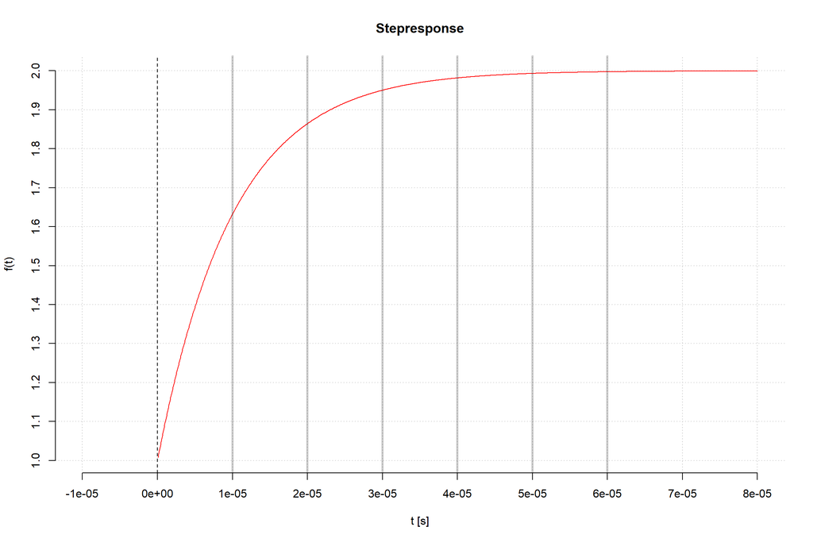

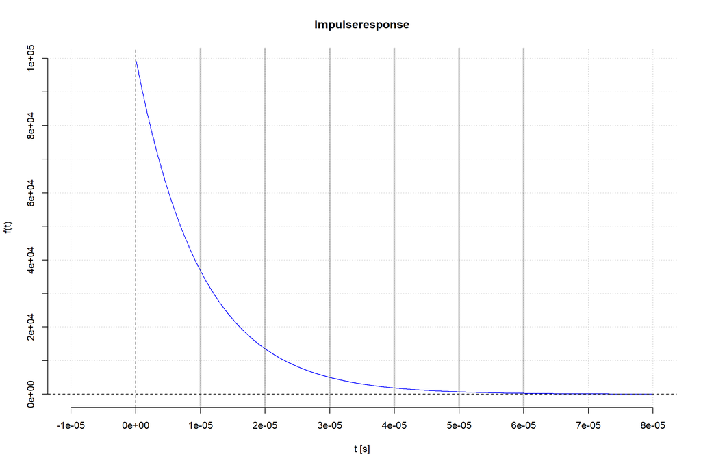

## Opgave 13

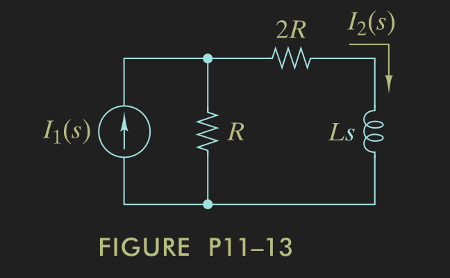

> Find the current transfer function T_I(s) = I_2(s)/I_1(s) in Figure P11–13. Select values of R and L so that T_I(s) has a pole at s = - 377 rad/s

Dette er en std. strømdeler.

Derfor gælder:

$$T_I(s) = \frac{I_2(s)}{I_1(s)} = \frac{Y_2(s)}{Y_1(s)+Y_2(s)}$$

Hvor:
$$Y_1 = \frac{1}{R} \quad \frac{1}{Y_2 = Ls + 2R}$$

Dette giver:

$$\frac{I_2(s)}{I_1(s)} = \frac{\frac{1}{Y_2 = Ls + 2R}}{\frac{1}{R}+\frac{1}{Y_2 = Ls + 2R}}$$

En omskrivning giver:

$$\frac{Y_2(s)}{Y_1(s)+Y_2(s)} = \frac{Z_1(s)}{Z_1(s)+Z_2(s)}$$

Derfor:

$$T_I(s)= \frac{R}{3R+Ls} = \frac{\frac{R}{L}}{\frac{3R}{L}+s}$$

Dette giver en pol i $-\frac{3R}{L}\;\mathrm{rad/s}$.

#### Polen i -377…

Der vælges en modstand: $4k7\Omega$.

Derfor:

$-377 = -\frac{3\cdot 4k7}{L} \to L =\frac{3 \dot 4k7}{377} = 37.4 \;\mathrm{H}$

$$T_I(s)= \frac{\frac{4k7\Omega}{37.4\;\mathrm{H}}}{\frac{3\cdot4k7\Omega}{37.4\;\mathrm{H}}+s}$$

## Opgave 15

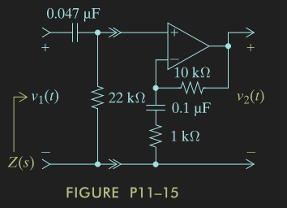

> Find the voltage transfer function T_V(s) = V_2(s)/V_1(s) of the cascade connection in Figure P11–15. Locate the poles and zeros of the transfer function

### Transfer function

KomponentID:

$C_1 = 0.047 \mu F \;$ $C_2 = 0.1 \mu F \;$

$R_1 = 22k\Omega\;$ $R_2 = 1k\Omega \;$ $R_3 = 10k\Omega \;$

#### Venstresiden

Denne del af kredsløbet er en spændingsdeler bestående af $C_1$ og $R_1$

$$v_1(t) = \frac{R_1}{R_1+C_1}$$

Laplacetransformationen giver:
$$T_{Vdivider}(s) = \frac{R_1}{R_1+\frac{1}{C_1s}}$$

#### Højresiden

Operationsforstærkeren er koblet som en **ikke** inverterende forstærker. Derfor:
$$T_{Vopamp}(s) = \frac{Z_1+Z_2}{Z_2}$$

Hvor:
$$Z_1 = R_3 \quad Z_2 = \frac{1}{C_2s}+R_2$$

Dermed:

$$T_{Vopamp}(s)=\frac{R_3+\frac{1}{C_2s}+R_2}{\frac{1}{C_2s}+R_2}$$

Med de rigtige værdier indsat:

$$T_{Vdivider}(s)= \frac{22k\Omega}{22k\Omega+\frac{1}{0.047\mu F s}} = \frac{s}{s+967.1}
\\
T_{Vopamp}(s)=\frac{10k\Omega+\frac{1}{0.1 \mu F s}+1k\Omega }{\frac{1}{0.1 \mu F s}+1k\Omega } = \frac{11(s+909.1)}{s+10000}$$

Hvorfor:

$$T_V(s) = T_{Vdivider}(s) \cdot T_{Vopamp}(s)$$

$$T_V(s) = \frac{C_1 R_1 s \cdot(C_2(R_2+R_2)s+1)}{(C_2R_2s+1)(C_1R_1s+1)}$$

$$T_V(s) = \frac{s}{s+967.1} \cdot \frac{11(s+909.1)}{s+10000}$$

$$\boxed{
T_V(s) = \frac{11s(s+909.1)}{(s+967.1)(s+10000)}
}$$
Det ses at funktionen har ét nulpunkt: $Z_1 = -909.1 \; rad/s$

Desuden er der to poler: $p_1 = -967.1\; rad/s \quad p_2 = -10000\; rad/s$

## Opgave 17

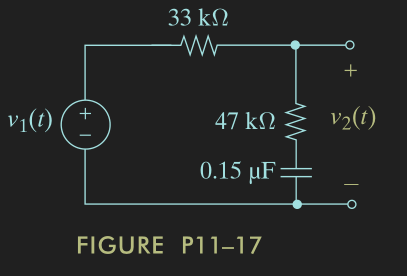

> Find the impulse response at v_2(t) in Figure P11–17. Find the circuit’s step response.

### Transfer function

Da det er en spændingsdeler gør flg. sig gældende - *efter en laplacetransformation*:

$$V_2(s) = V_1(s)\;\cdot\; \frac{R_2+\frac{1}{Cs}}{R_1+R_2+\frac{1}{Cs}}$$

Omskrevet[^1]:
$$\underset{Y(s)}{\underbrace{V_2(s)}} = \underset{X(s)}{\underbrace{V_1(s)}}\;\cdot\; \underset{T_V(s) \; \lor \; H(s)}{\underbrace{\frac{R_2Cs+1}{R_1Cs+R_2Cs+1}}}$$

### Transfer function

$$T_V(s)=\frac{R_2Cs+1}{R_1Cs+R_2Cs+1}$$

KomponentID:

$$R_1 = 33k\Omega\\
R_2 = 47k\Omega\\
C = 0.15 \mu F$$

$$T_V(s)=\frac{47k\Omega \cdot 0.15 \mu F \cdot s+1}{33k\Omega \cdot0.15 \mu F s+47k\Omega \cdot 0.15 \mu F s+1} =
\frac{0.5875\cdot(s+141.8)}{s+83.33}$$
Her ses det at et enkelt nulpunkt er at finde $z_1 = -141.8 \; rad/s$ og en enkelt pol $p_1 = -83.33 \; rad/s$

### Impulserespons

Ved at gøre følgende:
$$v_{impulse}(t)=
\mathcal{L}^{-1}\left\{
T_V(s)
\right\}
=
\mathcal{L}^{-1}\left\{
\frac{0.5875\cdot(s+141.8)}{s+83.33}
\right\}$$
Dette giver:
$$\boxed{
v_{impulse}(t) =
0.5785 \cdot \left(\delta(t)+58.47e^{-83.33t}\right)\cdot u(t)
}$$

### Steprespons

Ved at gøre følgende:

$$v_{step}(t)=\mathcal{L}^{-1}\left\{
\frac{1}{s} \cdot H(s)
\right\}
=
\mathcal{L}^{-1}\left\{
\frac{1}{s} \cdot T_V(s)
\right\}
=
\mathcal{L}^{-1}\left\{
\frac{0.5875\cdot(s+141.8)}{s^2+83.33s}
\right\}$$

Dette giver:

$$\boxed{
v_{step}(t) = (0.5875\cdot(1.702-0.702e^{-83.33t}))\cdot u(t)
}$$

### Driving point impedans

Vi har følgende KVL loop:

$$v_1(t)=v_r+v_r+v_c$$
Dette laplace transformeres:

$$\mathcal{L}^{-1}\left\{
v_1(t)
\right\}
=
\mathcal{L}^{-1}\left\{
v_{R1}(t)
\right\} +
\mathcal{L}^{-1}\left\{
v_{R2}(t)
\right\} +
\mathcal{L}^{-1}\left\{
v_C(t)
\right\}$$

og giver:
$$V_1(s) = V_{R1}(s)+V_{R2}(s)+V_C(s)$$

En let omskrivning

$$V_1(s)= I(s)(R_1+R_2)+ \frac{1}{Cs} I(s)$$

Dermed:

$$\frac{V_1(s)}{I(s)} = R_1+R_2 + \frac{1}{Cs}$$

og vi har driving point impedansen:

$$Z(s) = \frac{CR_1s+CR_2s+1}{Cs}$$

og vi har driving point impedansen / med værdier!:
$$\boxed{
Z(s) = \frac{80000\cdot(s+83.33)}{s}
}$$

## Designopgave 23

Vi har :

$$T(s) = \frac{200}{s+1000}$$

Omskrivning:

$$T(s) = \frac{\frac{200}{s}}{\frac{1000}{s}+1}$$

Giver:

$$Z_1 = \frac{1000}{s}+1 - \frac{200}{s} \quad Z_2 = \frac{200}{s}$$
$$Z_1 = \frac{800}{s}+1 - \frac{200}{s} \quad Z_2 = \frac{200}{s}$$

Derfor :
$$Z_1 = \frac{1}{800}µF + 1 \Omega \quad Z_2 = \frac{1}{200µF}$$

Skalering til $C_1 = 0.5µF$

$$\frac{1}{800}µF \cdot \frac{1}{k} = 0.5µF \to k = 2500$$

Derfor:

$$C_1 = 0.5µF \quad C_2 = 2µF \quad R = 2500\Omega$$

## Opgave 34

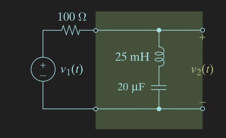

> The circuit in Figure P11–34 is in the steady state with v1(t) = 5 cos 1414.21t V. Find v2_SS(t). Repeat for v1(t) = 5cos 1 kt V. And without doing any calculations, repeat for v_1(t) = 5 V.

Vi har:

$$v_{1ss}(t) = 5 \cos(1414.21t)$$

Dette giver:
$$v_A = 5 \quad \omega = 1414.21$$

Transfer funktionen der påvirker systemet:

$$T_v(s) = \frac{Ls+\frac{1}{Cs}}{R+Ls+\frac{1}{Cs}}$$

Med værdier:

$$T_v(s) = \frac{25\;\mathrm{mH}s+\frac{1}{20\;\mathrm{µF}s}}{100\;\mathrm{\Omega}+25\;\mathrm{mH}s+\frac{1}{20\;\mathrm{µF}s}} = \frac{s^2+2\cdot10^6}{s^2+4\cdot10^3s+2\cdot10^6}$$

Omskrivning til frekvensdomænet:

$$T_v(\omega j) = \frac{\omega j^2+2\cdot10^6}{\omega j^2+4\cdot10^3\omega j+2\cdot10^6}$$

Amplitude og fase:
$$|T_v(s)|= \frac{|\omega^2-2\cdot10^6|}{\sqrt{\omega^4+12\cdot 10^6 \omega^2+4\cdot10^{12} }}$$

$$\angle T_v(s) = \arctan\left( \frac{4000\omega}{\omega^2-2\cdot 10^6} \right)$$

Derfor kan følgende opskrives:

$$v_{2ss}= v_A |T_v(\omega j)|\cos(\omega t + \phi + \angle{T(j\omega)})\; \mathrm{V}$$

Altså:
$$v_{2ss}= 5 \cdot |T_v(\omega j)| \cdot \cos(1414.21 t + \angle{T(j\omega)})\; \mathrm{V}$$

Med $\omega = 1414.21$
$$|T_v(s)| = 1.781\cdot 10^{-6} \quad \angle T_v(s) = -90$$
$$v_{2ss}= 5\cdot 1.781\cdot 10^{-6} \cdot \cos(1414.21 t -90) = 8.91\cos(1414.21-90)\; \mathrm{µV}$$

## Opgave 35

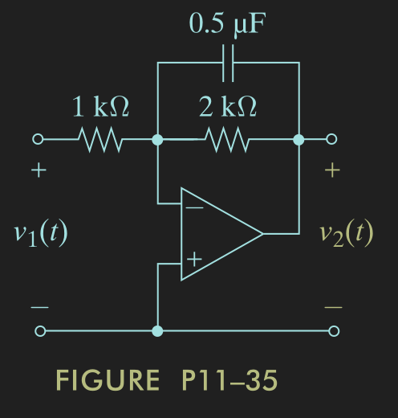

> The circuit in Figure P11–35 is in the steady state with v_1(t) = 10 cos 500t V. Find v_2SS(t).  
> Repeat for v_1(t) = 10 cos 1 kt V, and for v1(t) = 10 cos 10 kt V .  
> Where is the pole located?

KomponentID:

$$R_1 = 1k\Omega\\
R_2 = 2k\Omega\\
C = 0.5 \mu F$$

### Transfer function

Da det er en inverterende opsætning gælder flg.

$$T_V(s) = \frac{-Z_2}{Z_1}$$

Hvor
$$Z_1 = R_1 \quad Z_2 = \frac{R_2 \cdot \frac{1}{Cs}}{R_2+\frac{1}{Cs}}$$

Derfor:

$$T_V(s) = \frac{-\left( \frac{R_2 \cdot \frac{1}{Cs}}{R_2+\frac{1}{Cs}} \right)}{R_1}$$
Medfører:
$$T_V(s)= \frac{-R_2}{R_1(R_2Cs+1)}$$

Med værdierne indsat:

$$T_V(s) = \frac{-2000}{s+1000}$$

Denne funktion har én pol: $p_1 = -1000\; rad/s$

### Impulse response

For at finde impulsresponenet:

$$v_{impulse}(t)=
\mathcal{L}^{-1}\left\{
T_V(s)
\right\}
=v_{impulse}(t)=
\mathcal{L}^{-1}\left\{
\frac{-2000}{s+1000}
\right\}$$

Dette medfører:
$$v_{impulse}(t)= -2000 e^{-1000t} u(t)$$

## Opgave 37

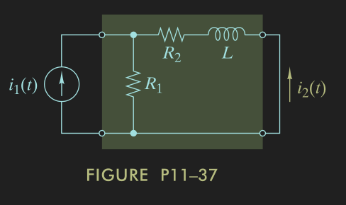

> The circuit in Figure P11–37 is in the steady state with i1(t) = 10 cos 50kt mA, R1 = 100 ohm, R2 = 400 ohm, and L = 100 mH. Find i2SS(t). Repeat for i1(t) = 10 cos 5kt mA. Where is the pole located?

Vi har:

$$i(t)=10 \cos 50kt \; \mathrm{mA} \quad R_1 = 100 \Omega \quad R_2 = 400 \quad \omega L = 100 \mathrm{mH}$$

Derfor:

$$\frac{I_2(s)}{I_1(s)} = \frac{Z_1}{Z_1+Z_2}$$

Hvor:
$$\quad Z_1 = 100 \Omega \quad Z_2 = 400 \omega + 100 \mathrm{mH} s$$

Dermed:

$$T_I(\omega j)= \frac{100}{500+100\cdot10^{-3}s} = \frac{1000}{\omega j+5000} = \frac{5\cdot10^6}{w^2+25\cdot10^6}- j \frac{1000\omega}{\omega^2+25\cdot10^6}$$

Herefter findes længden..

$$|T_I(\omega)| = \frac{1000}{\sqrt{w^2+25\cdot10^6}} \quad \angle T_v(\omega) = -\arctan(200\cdot 10^6 \omega)$$

Med $\omega = 50k\; rad/s$:

$$|T_v(50k)| = 19.9\cdot 10^{-3} \quad \angle T_v(50k) = -84.29$$

Derfor:

$$\boxed{
i_2(t) = 199 \cos(50kt -84.29) µA
}$$

Med $\omega = 5k\; rad/s$:

## Opgave 70

> Design a passive circuit to realize the transfer function below using only resistors, capacitors, and inductors. Scale the circuit so that all inductors are 50 mH or less.

Vi har:

$$T_v(s)=\frac{s^2}{(s+2000)^2}$$

En omskrivning giver:

$$T_V(s)=\frac{s^2}{s+4000s+4000000} = \frac{s}{s+4000+\frac{4000000}{s}}$$

$$Z_2 = s \quad Z_1 = s+4000+\frac{4000000}{s}-s = 4000+\frac{4000000}{s}$$

$$Z_2 = 1H \quad Z_1 = 4k\Omega + \frac{1}{4000000} = 4k\Omega + 250\;\mathrm{nF}$$

Spændingsdeler:
$$T_v(s) = \frac{Z_2}{Z_1+Z_2}$$

Omskaleret så $L < 50mH$

$$Z_2\cdot k = 50mH \to k = 0.050$$
$$Z_1 \cdot k = 4 k\Omega \cdot 0.05 + 250\;\mathrm{nF}\cdot \frac{1}{0.05}$$

Derfor:

Spændingsdeler:
$$T_v(s) = \frac{Z_2}{Z_1+Z_2}$$
Hvor

$$\boxed{
Z_1 = 200\Omega + 5\;\mathrm{µF} \qquad Z_2 = 50\;\mathrm{mH}
}$$

## Opgave 71

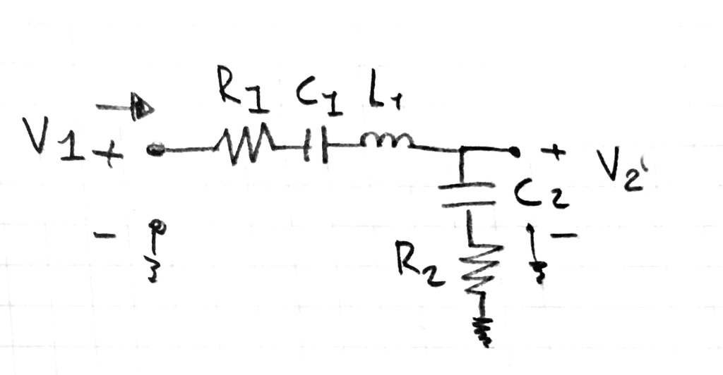

Funktionen vist som spændingdeler.

> A circuit is needed to realize the transfer function listed below.
> - Design the circuit using two OP AMPs.
> - Design the circuit using only one OP AMP.
> - Design the circuit using no OP AMPs.

> **In all cases, scale the circuit so that all parts use practical values.**

$$T_v(s) = \pm \frac{(s+125)\cdot(s+500)}{(s+250)\cdot(s+1000)}$$

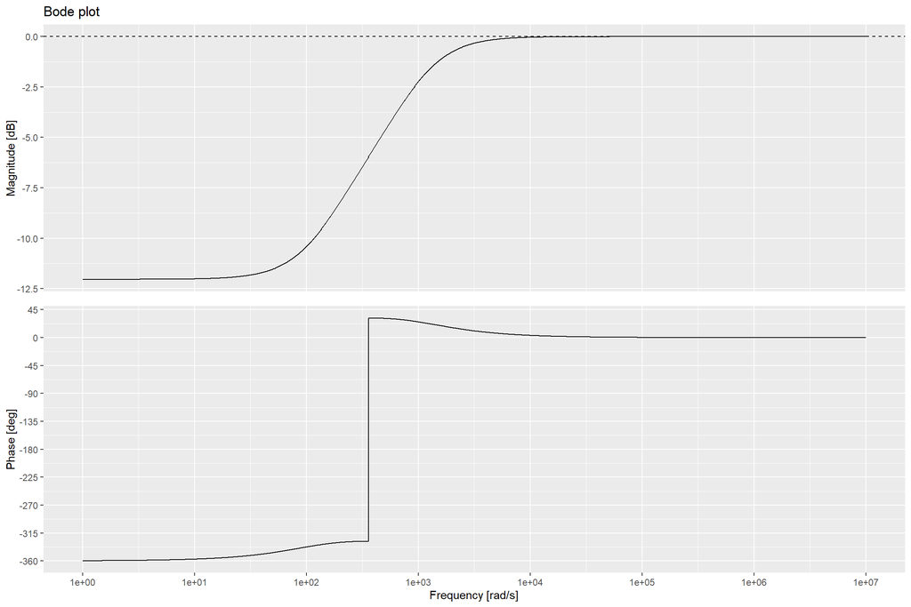

Det at: Poler:
$$p_1 = -250 \quad p_2 = -1000$$

Nulpunkter:
$$z_1 = -125 \quad z_2 = -500$$

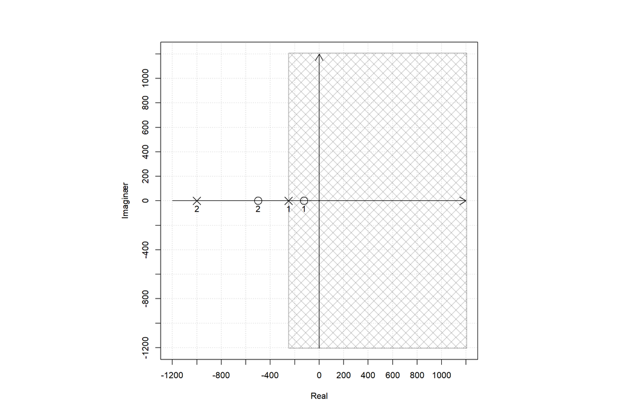

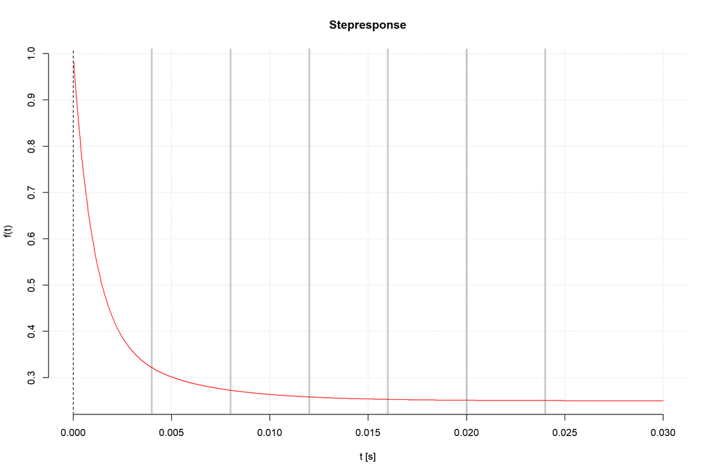

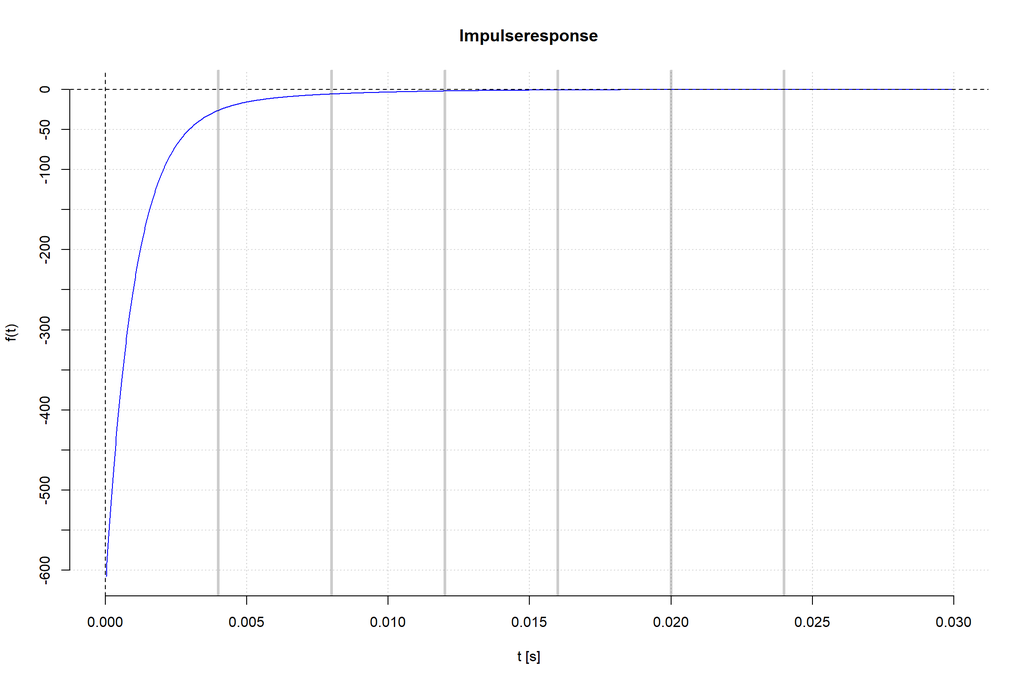

Bemærkelses værdigt er det vel at nulpunkterne ligger i en faktor $\frac{1}{2}$.

Omskrivning giver:

$$T_v(s)= \pm \frac{s^2+625s+62500}{s^2+1250s+250000}$$

$$T_v(s)=\pm \frac{s+625+\frac{62500}{s}}{s+1250+\frac{250000}{s}}$$

#### Spændingsdeler

Vi har ved en std. spændingsdeler:
$$V_2(s) = V_1(s) \cdot \frac{Z_2}{Z_1+Z_2}$$

Hvor:
$$Z_1 = s+625+\frac{62500}{s} \quad Z_2 = s+1250+\frac{250000}{s} - s+625+\frac{62500}{s}$$

$$Z_2 = \frac{312500}{s}+1875$$

Dette giver at kredsløbet ville kunne bygges af flg:

$$Z_1 = 1H + 625\Omega + \frac{1}{62500}F = 1H + 625\Omega + 16µF \quad Z_2 = \frac{1}{312500}+1875\Omega = 3.2µF + 1875\Omega$$

$$R_1 = 625 \Omega \quad
R_2 = 1875 \Omega \quad
C_1 = 16µF \quad
C_2 = 3.2µF \quad
L_1 = 1H$$

$$R_1 = 62.5\Omega \quad
R_2 = 187.5 \Omega \quad
C_1 = 160µF \quad
C_2 = 32µF \quad
L_1 = 100mH$$

#### Single OP-AMP.

##### Non inverter:

$$V_2(s) = V_1(s) \cdot \frac{Z_1+Z_2}{Z_2}$$

Hvor den interessante del er :

$$\frac{Z_1+Z_2}{Z_2}$$

Derfor:
$$\frac{Z_1+Z_2}{Z_2} = \pm \frac{(s+125)\cdot(s+500)}{(s+250)\cdot(s+1000)}$$

$$\frac{Z_1+Z_2}{Z_2} = \pm \frac{s+625+\frac{62500}{s}}{s+1250+\frac{250000}{s}}$$

##### Inverterende:

$$V_2(s) = V_1(s) \cdot (-\frac{Z_2}{Z_1})$$
Dette giver:

$$\frac{-Z_2}{Z_1} = \pm \frac{s+625+\frac{62500}{s}}{s+1250+\frac{250000}{s}}$$

$$Z_2 = -(s + 625 + \frac{1}{62500}) =-(1H + 625 \Omega + 16µF)$$

$$Z_1 = s + 1250 + \frac{1}{250000} - Z_2= 2H + 1875 \Omega + 20µF$$

[^1]: Er $T_V(s) = H(s)$ ?